# The Influence of Text Characteristics for Email Classification

Author

Group 22

```r
library(tibble)
library(ggplot2)
library(dplyr)
library(gt)
library(patchwork)
library(gridExtra)
library(broom)
library(knitr)
library(GGally)
library(sjPlot)
library(MASS)
```

```r
email<-read.csv("dataset22.csv")
```

```r
email$yesno<-as.factor(email$yesno)
```

# 1 Introduction

This analysis focuses on identifying the characteristics of email messages that are predictive of spam. With the rise of unwanted and potentially harmful emails, effective spam detection has become a crucial challenge. By analysing patterns in email content, structure, and metadata, we aim to identify the distinguishing features that separate spam from legitimate messages. Gaining a deeper understanding of these characteristics can lead to the development of smarter, more accurate filtering systems that reduce inbox clutter and protect users from scams and other malicious activities.

# 2 Exploratory Data Analysis

## 2.1 Data Visualization

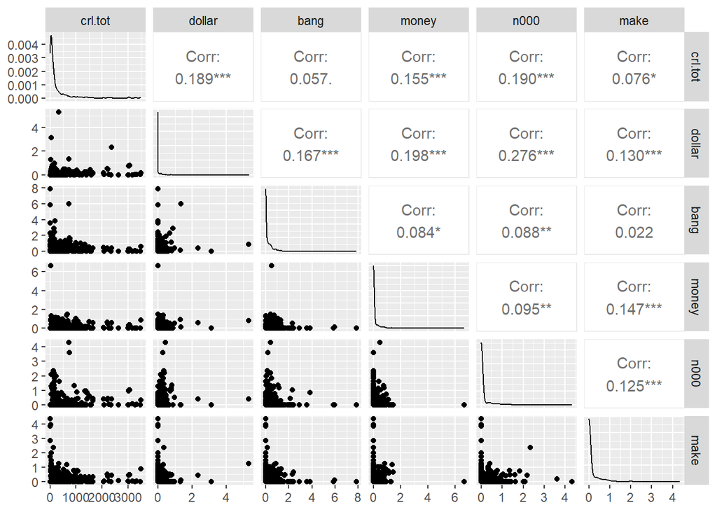

Figure 1: Correlations between each variables.

```r
ggpairs(email[,1:6]) +
  theme(plot.background = element_rect(
    fill = "transparent",
    colour = NA,
    size = 1))
```

By Figure 1, we see that the correlations between each explanatory is not larger than 0.4, which means the relationship between each variable is weak. It suggests that there is not much concern about multicollinearity. From the scatter plot, there are some points are far away from cluster. Those points can be removed as outliers to improve model’s stability.

## 2.2 Removing Outliers

```r
remove_outliers_rowwise_zscore <- function(df) {
  df_clean <- df
  for (col_name in names(df)) {
    if (is.numeric(df[[col_name]])) {
      z_scores <- scale(df[[col_name]])
      df_clean <- df_clean[abs(z_scores) <= 3, ]
    }
  }
  return(na.omit(df_clean))
}
email_clean <- remove_outliers_rowwise_zscore(email)
```

To minimize outliers while preserving as much information as possible, z score are used to remove outliers.

## 2.3 Scaling Data

```r
range_table <- apply(email_clean[-7], 2, range)
range_df <- as.data.frame(t(range_table))
colnames(range_df) <- c("Min", "Max")
range_df$Variables<-colnames(email_clean[-7])
gt(range_df[,c(3,1,2)])
```

Table 1: Range of each variables.

| Variables | Min | Max |
| --- | --- | --- |
| crl.tot | 1 | 1645.000 |
| dollar | 0 | 5.300 |
| bang | 0 | 5.942 |
| money | 0 | 6.660 |
| n000 | 0 | 4.320 |
| make | 0 | 4.340 |

After removing outliers, the Table 1 shows the range of each variable. It is clear that the range of the number of total length of uninterrupted sequences of capitals is extremely large than others. Hence, normalization are processed to reduce bias when large scale may dominates the cost function.

```r
email_clean$crl.tot<-scale(email_clean$crl.tot)
range_table <- apply(email_clean[-7], 2, range)
range_df <- as.data.frame(t(range_table))
colnames(range_df) <- c("Min", "Max")
range_df$Variables<-colnames(email_clean[-7])
gt(range_df[, c(3,1,2)]) %>%
  fmt_number(columns = everything(),decimals = 2)
```

Table 2: Range of each scaled variables.

| Variables | Min | Max |
| --- | --- | --- |
| crl.tot | −0.68 | 4.83 |
| dollar | 0.00 | 5.30 |
| bang | 0.00 | 5.94 |
| money | 0.00 | 6.66 |
| n000 | 0.00 | 4.32 |
| make | 0.00 | 4.34 |

After scaling，the range of the number of total length of uninterrupted sequences of capitals is shrank to a range which is close to others.

## 2.4 Data Visualization

In this section, we analyze the boxplots of key textual features to compare their distributions between spam and non-spam emails. Boxplots provide an insightful visualization of how different variables behave in each category, highlighting key statistics such as medians, interquartile ranges (IQRs), and potential outliers.

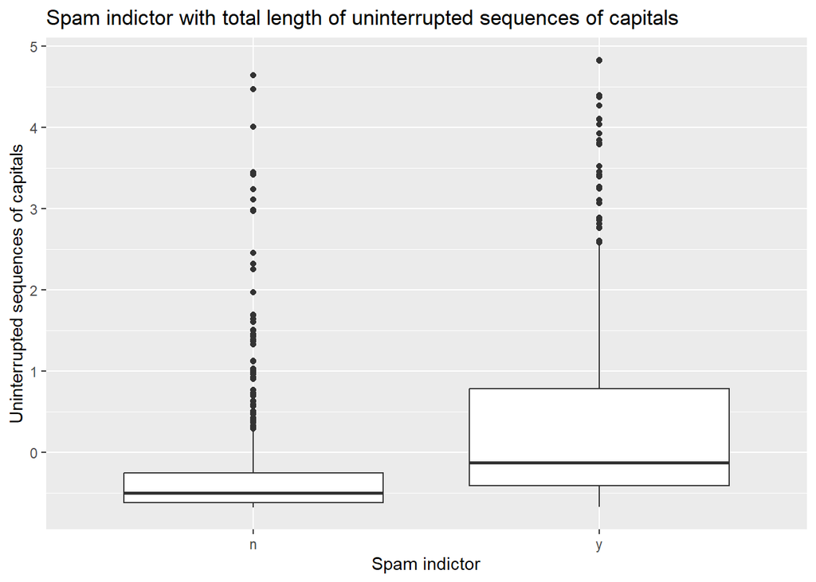

Figure 2: Boxplot of total length of uninterrupted sequences of capitals.

```r
ggplot(email_clean, aes(x = yesno, y = crl.tot)) +
  geom_boxplot() +
  labs(x = "Spam indictor", y = "Uninterrupted sequences of capitals",
       title = "Spam indictor with total length of uninterrupted sequences of capitals")
```

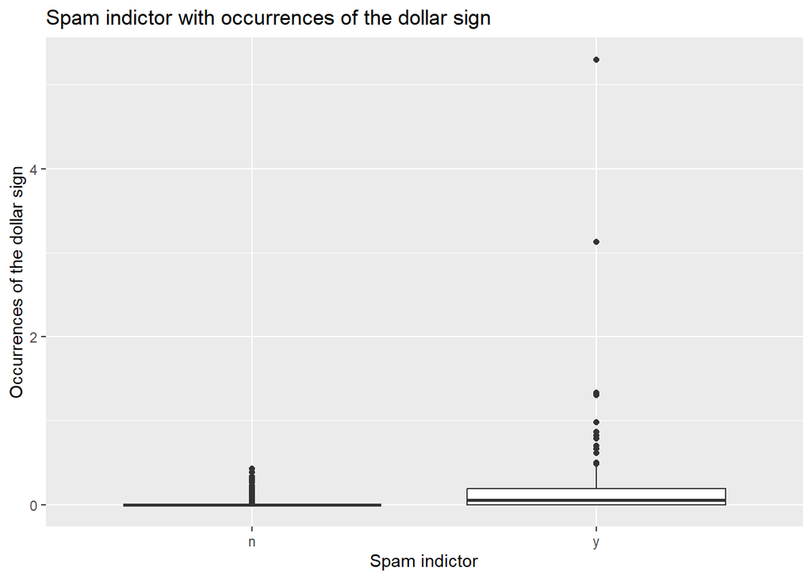

Figure 3: Boxplot of occurrences of the dollar sign.

```r
ggplot(email_clean, aes(x = yesno, y = dollar)) +
  geom_boxplot() +
  labs(x = "Spam indictor", y = "Occurrences of the dollar sign",
       title = "Spam indictor with occurrences of the dollar sign")
```

Next, we consider the occurrences of the dollar sign (“$”). The results indicate that spam emails have a significantly higher median frequency of “$” than non-spam emails. This suggests that spam messages frequently reference financial incentives, monetary amounts, or sales offers, reinforcing their promotional or fraudulent nature. The boxplot also displays a wide distribution with several extreme outliers, indicating that some spam emails heavily utilize the dollar sign to lure recipients with promises of wealth or investment opportunities.

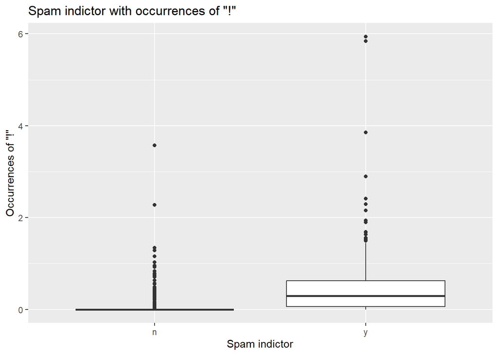

Figure 4: Boxplot of occurrences of ‘!’.

```r
ggplot(email_clean, aes(x = yesno, y = bang)) +
  geom_boxplot() +
  labs(x = "Spam indictor", y = 'Occurrences of "!"',
       title = 'Spam indictor with occurrences of "!"')
```

The third boxplot investigates the occurrences of the exclamation mark (“!”). The results demonstrate that spam emails contain a much higher median number of exclamation marks than non-spam emails. This aligns with the general tendency of spam messages to use excessive punctuation to create a sense of urgency or excitement. The presence of multiple outliers further emphasizes that some spam emails employ an abnormally high number of exclamation marks, making this a useful feature for distinguishing spam content.